# Cleaning the Data

This example assumes that the appropriate data is loaded into R already. Unfortunately this example assumes that this is just being used for Q3 2015 analysis, so the code would need to be edited in the future

```r
setwd("~/MIDAS GDP Model")
library(xlsx)
construction<- read.xlsx('Construction_Spending.xls', sheetIndex=1, sheetName=NULL, rowIndex=NULL, startRow=11, colIndex=2, as.data.frame=TRUE, header=TRUE)

employment<- read.xlsx('TotalNonfarmPayroll.xls', sheetIndex=1, sheetName=NULL, rowIndex=NULL,
                startRow=108, colIndex=2,
                as.data.frame=TRUE, header=FALSE)

gdp<- read.xlsx('GDP.xls', sheetIndex=1, sheetName=NULL, rowIndex=NULL,
                         startRow=11, endRow=929, colIndex=2,
                         as.data.frame=TRUE, header=TRUE)
```

### Data Set for Linear Regression Models with Autoregressive Errors

```r
library(zoo)
construction_quarters<- rollapply(construction[,1], width=3, mean, by=3)
#The numbers for September aren't in yet for Construction spending, so in this case, I average the last two values together an apend it to the end of the construction_quarters for a complete data set.
extra_value<- mean(construction[271:272,1])
construction_quarters<- append(construction_quarters, extra_value)


employment_quarters<- rollapply(employment[,1], width=3, mean, by=3)
```

Quick test that it worked properly

```r
construction_quarters[1] == mean(construction[1:3,1])
```

```
## [1] TRUE
```

```r
construction_quarters[2] == mean(construction[4:6,1])
```

```
## [1] TRUE
```

```r
employment_quarters[1] == mean(employment[1:3,1])
```

```
## [1] TRUE
```

```r
employment_quarters[2] == mean(employment[4:6,1])
```

```
## [1] TRUE
```

We then set all data sets as time series before we begin analysis

```r
construction_q_ts<- ts(construction_quarters, start = c(1993, 1), frequency=4)
employment_q_ts<- ts(employment_quarters, start = c(1947, 1), frequency=4)
gdp_q_ts<- ts(gdp,start = c(1947, 1), frequency = 4)

#colnames(construction_q_ts)<- c('construction')
#colnames(employment_q_ts) <- c('employment')
#colnames(gdp_q_ts)<- c('gdp')
```

### Removing Autocorrelation in GDP

The plot for GDP is not covariant stationary, but the first differincing is worth checking. I also take a look at the log of GDP as it is representitive of the compounding growth of the economy.

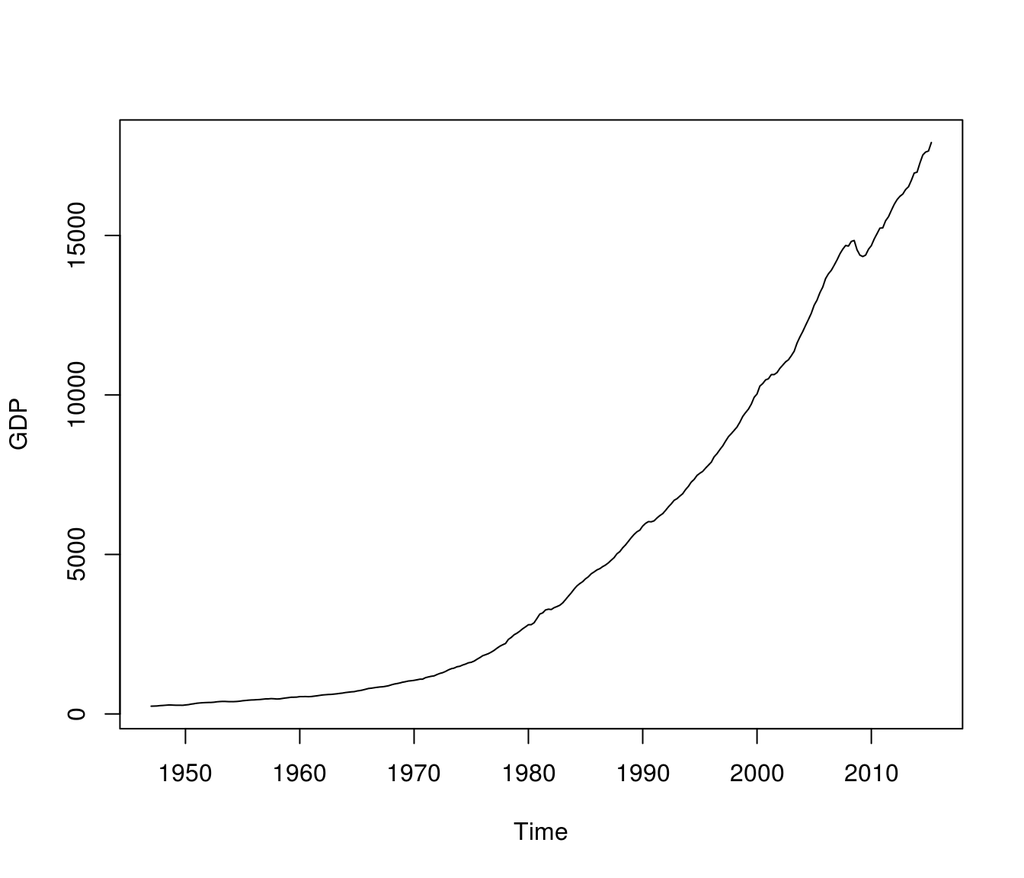

```r
plot(gdp_q_ts)
```

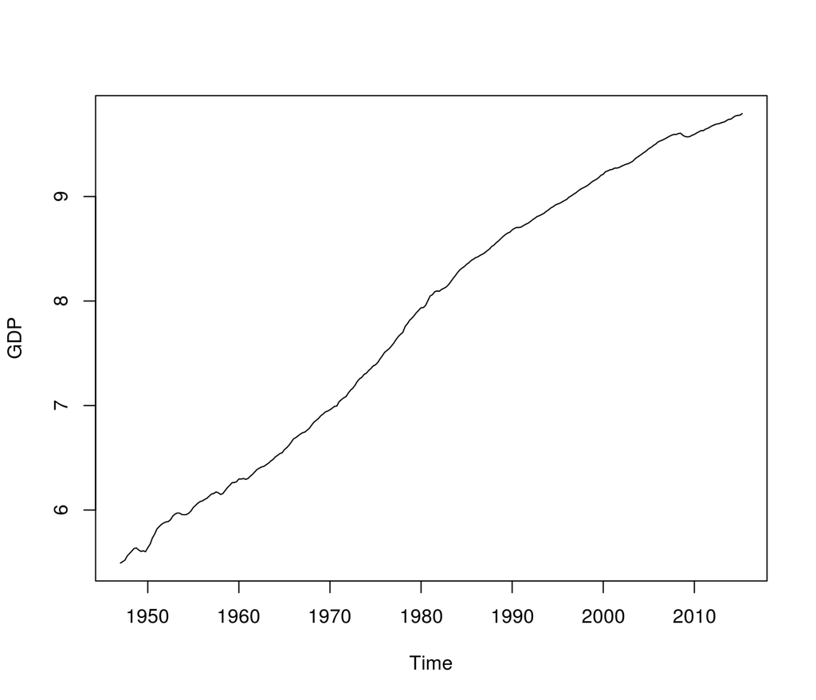

```r
plot(log(gdp_q_ts))
```

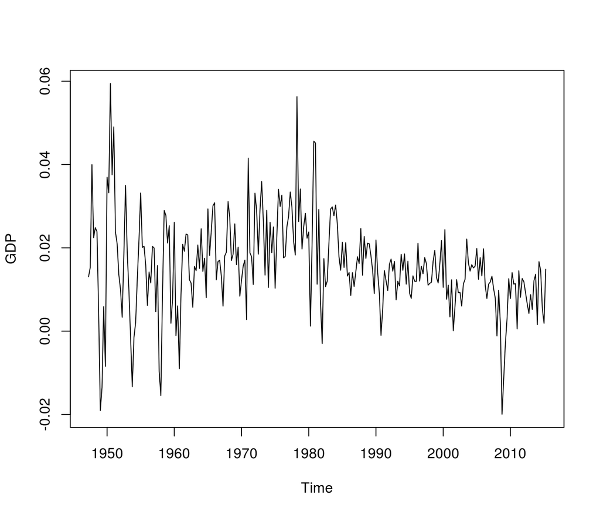

```r
plot(diff(log(gdp_q_ts)))
```

The first differencing of the log looks the most stationary and the Augmented Dickey-Fuller Test confirms this with a low p value.

```r
library(fUnitRoots)
adfTest(log(gdp_q_ts), lags = 10, type= c('c'))
```

```
##
## Title:
##  Augmented Dickey-Fuller Test
##
## Test Results:
##   PARAMETER:
##     Lag Order: 10
##   STATISTIC:
##     Dickey-Fuller: -2.0561
##   P VALUE:
##     0.2913
##
## Description:
##  Fri Oct  9 11:46:54 2015 by user:
```

```r
#Can't reject the null, so the series needs to be differenced
adfTest(diff(log(gdp_q_ts)), lags = 10, type= c('c'))
```

```
##
## Title:
##  Augmented Dickey-Fuller Test
##
## Test Results:
##   PARAMETER:
##     Lag Order: 10
##   STATISTIC:
##     Dickey-Fuller: -3.1594
##   P VALUE:
##     0.02405
##
## Description:
##  Fri Oct  9 11:46:54 2015 by user:
```

```r
# Reject the null, the data is stantionary
gdp_log_diff <-  diff(log(gdp_q_ts))
```

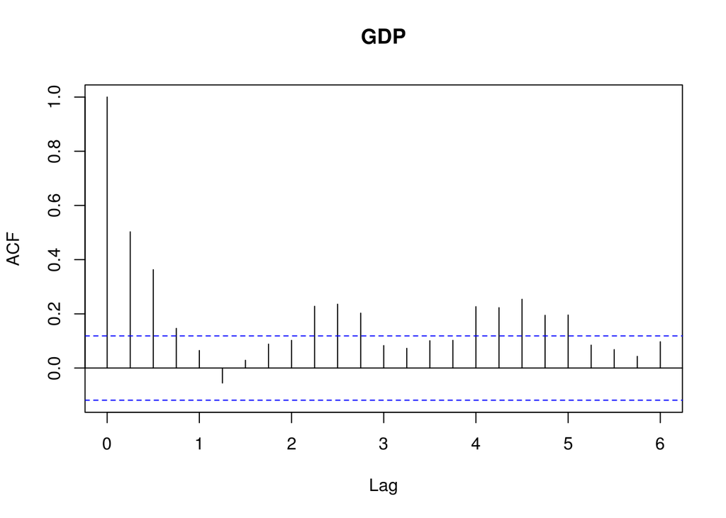

```r
library(tseries)
acf(gdp_log_diff)
```

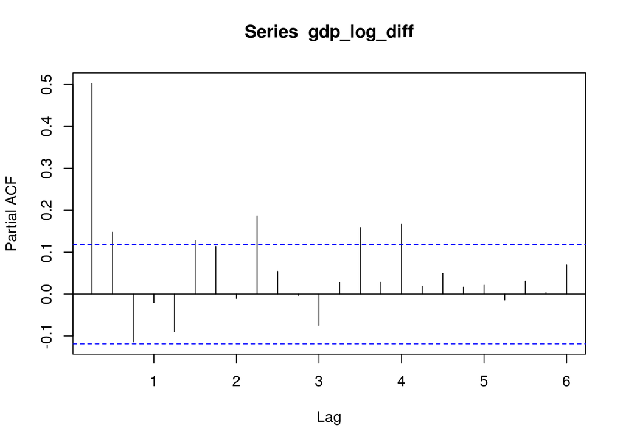

```r
pacf(gdp_log_diff)
```

```r
ar_3<- arima(gdp_log_diff, order= c(3,0,0))
ar_2<- arima(gdp_log_diff, order= c(2,0,0))
ar_1<- arima(gdp_log_diff, order= c(1,0,0))
```

ar_3 AIC: -1763.19 (the 3rd lag is not signifigant) ar_2 AIC: -1761.49 ar_1 AIC: -1757.46

ar_1 AIC is closest to zero, but the AR(2) model is signifigant in the second lag, and is called for when looking at the PACF of the log of GDP differences. Looking at the residuals of this model indicates there could be some seasonaility, specifically in the 5th and 9th lags. This is on an annual cycle in the period prior to the current period. This show up in both the ACF and PACF of the AR(2) residuals, so it makes it hard to tell immediately if the proper seasonal model is AR or MA, so there is a need to test both.

What is the difference between AR and MA?

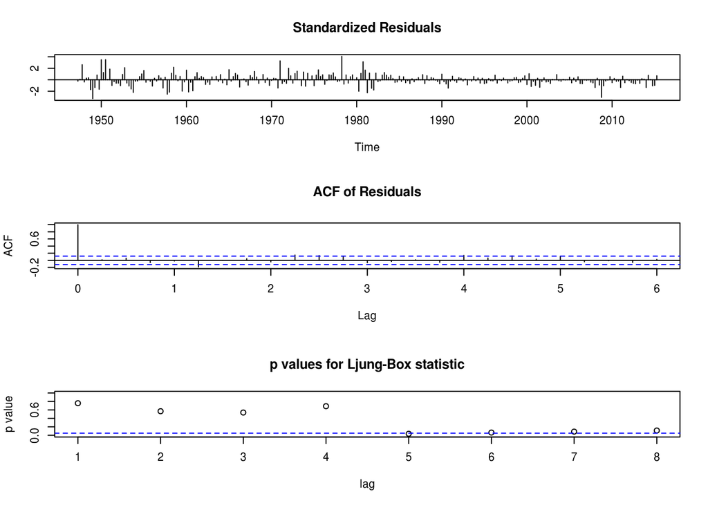

```r
tsdiag(ar_2,gof=8)
```

```r
Box.test(ar_2$residuals,8,type='Ljung')
```

```
##
##  Box-Ljung test
##
## data:  ar_2$residuals
## X-squared = 12.954, df = 8, p-value = 0.1135
```

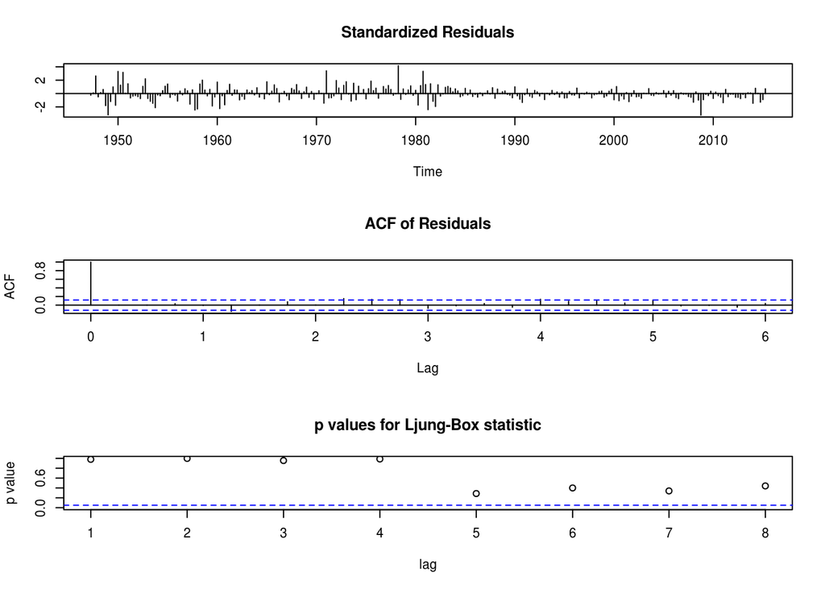

```r
ar2_ma2_sa2<- arima(gdp_log_diff, order= c(2,0,2), seasonal = c(2,0,0))
tsdiag(ar2_ma2_sa2,gof=8)
```

```r
Box.test(ar2_ma2_sa2$residuals,8,type='Ljung')
```

```
##
##  Box-Ljung test
##
## data:  ar2_ma2_sa2$residuals
## X-squared = 7.9151, df = 8, p-value = 0.4418
```

None of the seaonal ARs or MAs are statistically signifigant but both drop the AIC. But they don’t solve the problem in the ACF and PACF tests, so it’s really just a gut call to finding the best model.

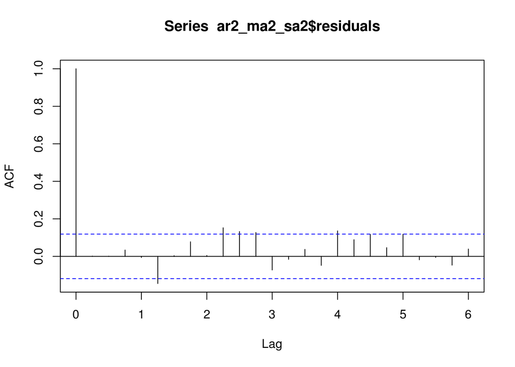

```r
acf(ar2_ma2_sa2$residuals)
```

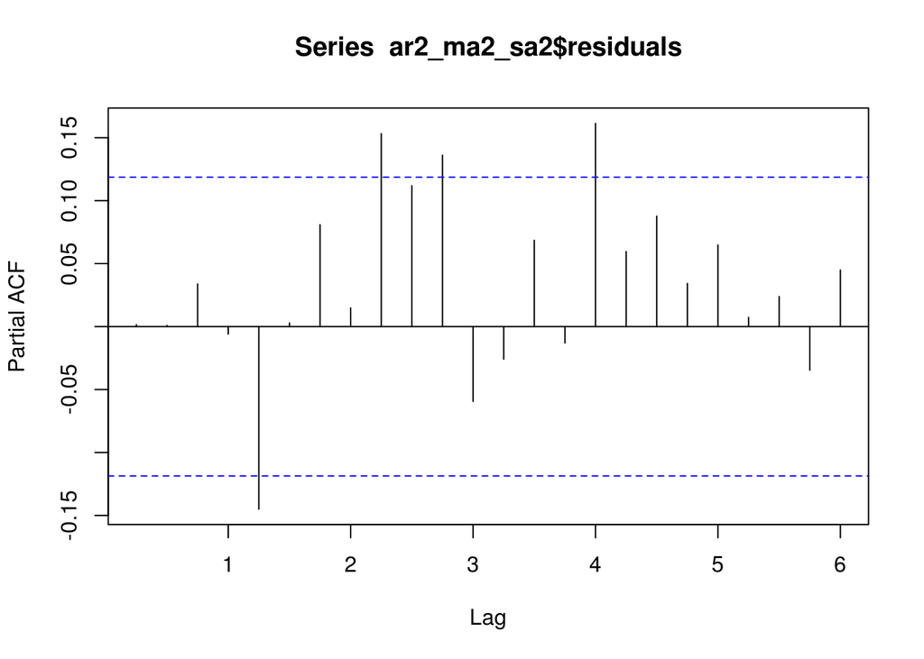

```r
pacf(ar2_ma2_sa2$residuals)
```

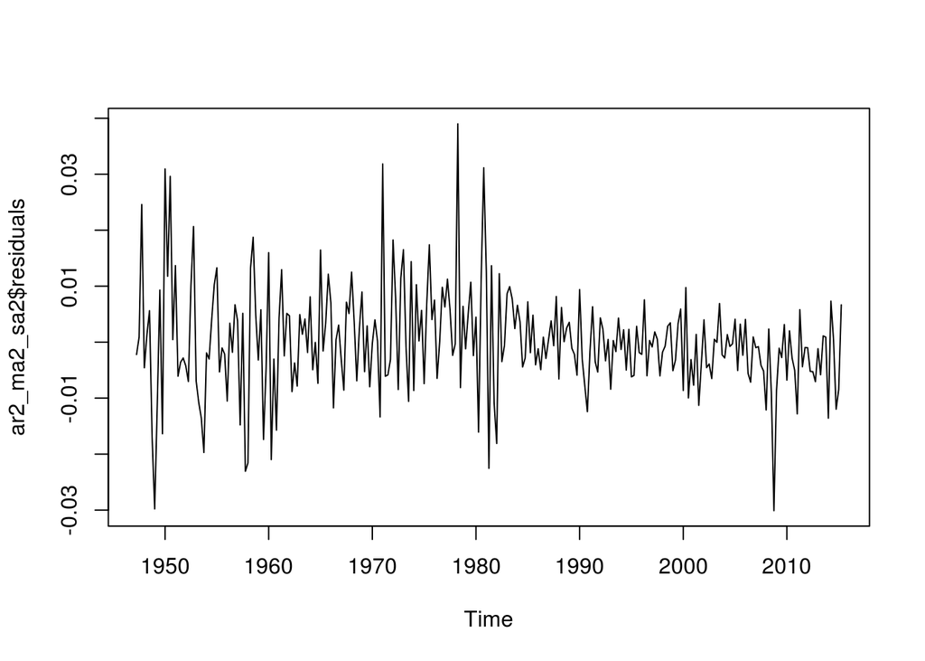

```r
plot(ar2_ma2_sa2$residuals)
```

When looking at a plot of the residuals, it is easy to see there are two distict periods in the economy since GDP has been available, which could be creating the issues with our data. The first period runs from 1947 to the early 1980s. During this period, it’s easy to see a lot more variance common in the variables. There are several options. The two most common would be to just ignore the beginning of the data. This is commonly done with macro comparisons of the U.S. economy since the period since 1980 is seen as the ‘modern’ economy.

```r
library(rugarch)
```

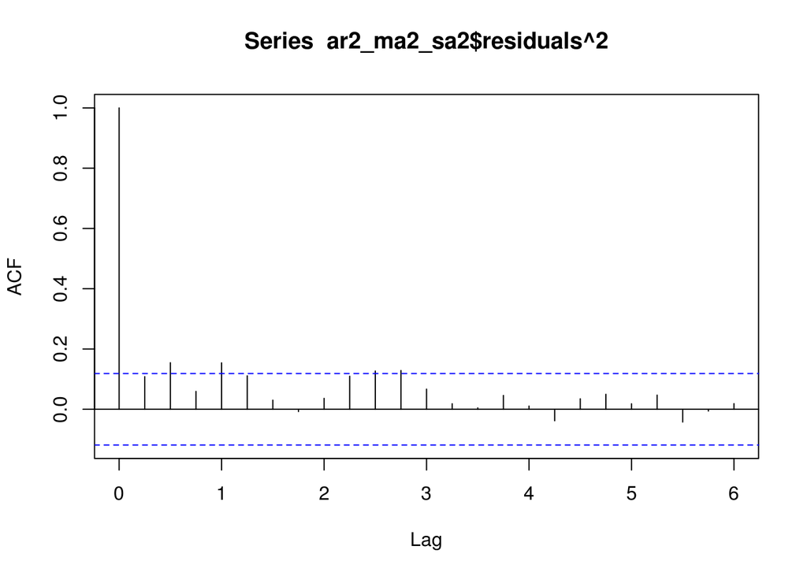

```r
acf(ar2_ma2_sa2$residuals^2)
```

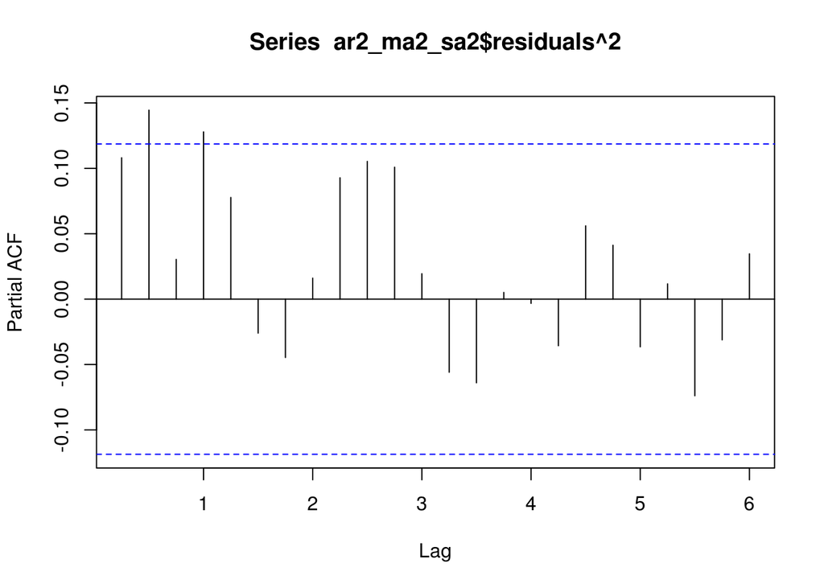

```r
pacf(ar2_ma2_sa2$residuals^2)
```

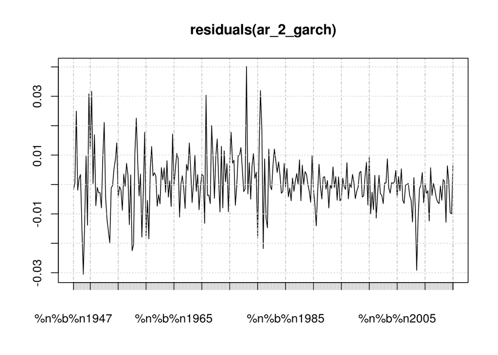

```r
# to handel the seasonailty, you need to pass through the data through the forecast package...
#1. First try fitting the returns using the "forecast" package which
#supports SARIMA.
#2. If you are satisfied with the residuals, pass them to rugarch (with
#armaOrder=c(0,0), include.mean=F and nothing else).

garch_1 <- ugarchspec(mean.model = list(armaOrder = c(2, 2), include.mean = TRUE), variance.model = list(model = "sGARCH", garchOrder = c(1, 1)),distribution.model = "norm")

ar_2_garch<- ugarchfit(garch_1, data=gdp_log_diff)

plot(residuals(ar_2_garch))
```

```r
Box.test(residuals(ar_2_garch),8,type='Ljung')
```

```
##
##  Box-Ljung test
##
## data:  residuals(ar_2_garch)
## X-squared = 8.3886, df = 8, p-value = 0.3965
```

So there is still a lot of conditional heterosedasticity, but the model is worth forcasting to see if it gives better predictions.

### Adding employment as a regressor

Since gdp was differenced and is not out for the 3rd Quarter at the time of the analysis (even though it is over), I need to strip out the first and last values to line up with the same number of values for GDP. (Make sure this makes logical sense).

```r
#Transform back to data frame, cut out last value and difference
#employment
employment_quarters<- rollapply(employment[,1], width=3, mean, by=3)
employment_quarters_diff <- diff(employment_quarters)
employment_quarters_diff <- data.frame(employment_quarters_diff)
employment_quarters_diff<- employment_quarters_diff[-274,]
employment_quarters_diff<- ts(employment_quarters_diff)
```

```r
em_log_diff<- diff(log(employment_quarters))
em_log_diff<- data.frame(em_log_diff)
em_log_diff<- em_log_diff[-274,]
simple_lm <- lm(gdp_log_diff~em_log_diff)
simple_lm <- lm(gdp_log_diff~employment_quarters_diff)
summary(simple_lm)
```

```
##
## Call:
## lm(formula = gdp_log_diff ~ employment_quarters_diff)
##
## Residuals:
##       Min        1Q    Median        3Q       Max
## -0.021374 -0.005920 -0.001015  0.005775  0.031584
##
## Coefficients:
##                           Estimate Std. Error t value Pr(>|t|)
## (Intercept)              1.114e-02  6.497e-04   17.15   <2e-16 ***
## employment_quarters_diff 1.283e-05  1.025e-06   12.52   <2e-16 ***
## ---
## Signif. codes:  0 '***' 0.001 '**' 0.01 '*' 0.05 '.' 0.1 ' ' 1
##
## Residual standard error: 0.008844 on 271 degrees of freedom
## Multiple R-squared:  0.3663, Adjusted R-squared:  0.3639
## F-statistic: 156.6 on 1 and 271 DF,  p-value: < 2.2e-16
```

A simple look at a linear model of employment’s effect on changes in gdp shows a strong relationship.

```r
ar_2_sa2_data <- arima(gdp_log_diff, order= c(2,0,2), seasonal = c(2,0,0), xreg = em_log_diff)
ar_2_sa2_data
```

```
##
## Call:
## arima(x = gdp_log_diff, order = c(2, 0, 2), seasonal = c(2, 0, 0), xreg = em_log_diff)
##
## Coefficients:
##           ar1     ar2     ma1      ma2     sar1     sar2  intercept
##       -0.0267  0.9127  0.1855  -0.6831  -0.0837  -0.0949     0.0102
## s.e.   0.1227  0.1428  0.1809   0.2443   0.0901   0.0668     0.0015
##       em_log_diff
##            1.2451
## s.e.       0.0806
##
## sigma^2 estimated as 4.721e-05:  log likelihood = 971.97,  aic = -1925.93
```

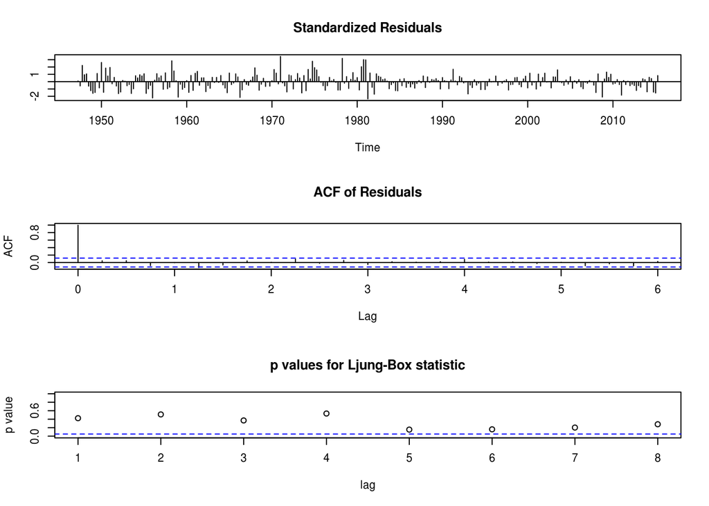

```r
tsdiag(ar_2_sa2_data,gof=8)
```

```r
Box.test(ar_2_sa2_data$residuals,8,type='Ljung')
```

```
##
##  Box-Ljung test
##
## data:  ar_2_sa2_data$residuals
## X-squared = 9.7739, df = 8, p-value = 0.2813
```

### MIDAS Models

```r
library(midasr)
#Edit employment data to fit
midas_employment<- ts(log(employment))
midas_employment<- diff(midas_employment)

#delete last 3 rows and first 3.. (is this right?)
midas_employment_diff<-midas_employment[-c(1,2,3, 823:825),]
midas_employment_diff<- ts(midas_employment_diff)
```

This is a quick look at the model without any ARIMA terms and all the stages of monthly employment are signifigant.

```r
#MIDSA model without the AR terms
midas_noar <- midas_r(gdp_log_diff ~  mls(midas_employment_diff,0:2,3), start=NULL, data = list(gdp_log_diff = gdp_log_diff, midas_employment_diff = midas_employment_diff))
summary(midas_noar)
```

```
##
##  Formula gdp_log_diff ~ mls(midas_employment_diff, 0:2, 3)
##
##  Parameters:
##                         Estimate Std. Error t value Pr(>|t|)
## (Intercept)            0.0114205  0.0008587  13.300  < 2e-16 ***
## midas_employment_diff1 0.6044070  0.2007125   3.011 0.002849 **
## midas_employment_diff2 1.3194427  0.3144483   4.196 3.69e-05 ***
## midas_employment_diff3 0.9818685  0.2739445   3.584 0.000401 ***
## ---
## Signif. codes:  0 '***' 0.001 '**' 0.01 '*' 0.05 '.' 0.1 ' ' 1
##
##  Residual standard error: 0.008603 on 269 degrees of freedom
```

```r
Box.test(ar_2_sa2_data$residuals,8,type='Ljung')
```

```
##
##  Box-Ljung test
##
## data:  ar_2_sa2_data$residuals
## X-squared = 9.7739, df = 8, p-value = 0.2813
```

```r
#MIDAS with trend line
trend <- 1:length(gdp_log_diff)
midas_trend <- midas_r(gdp_log_diff ~ trend+ mls(midas_employment_diff,0:2,3), start=NULL, data = list(gdp_log_diff = gdp_log_diff, midas_employment_diff = midas_employment_diff))
```

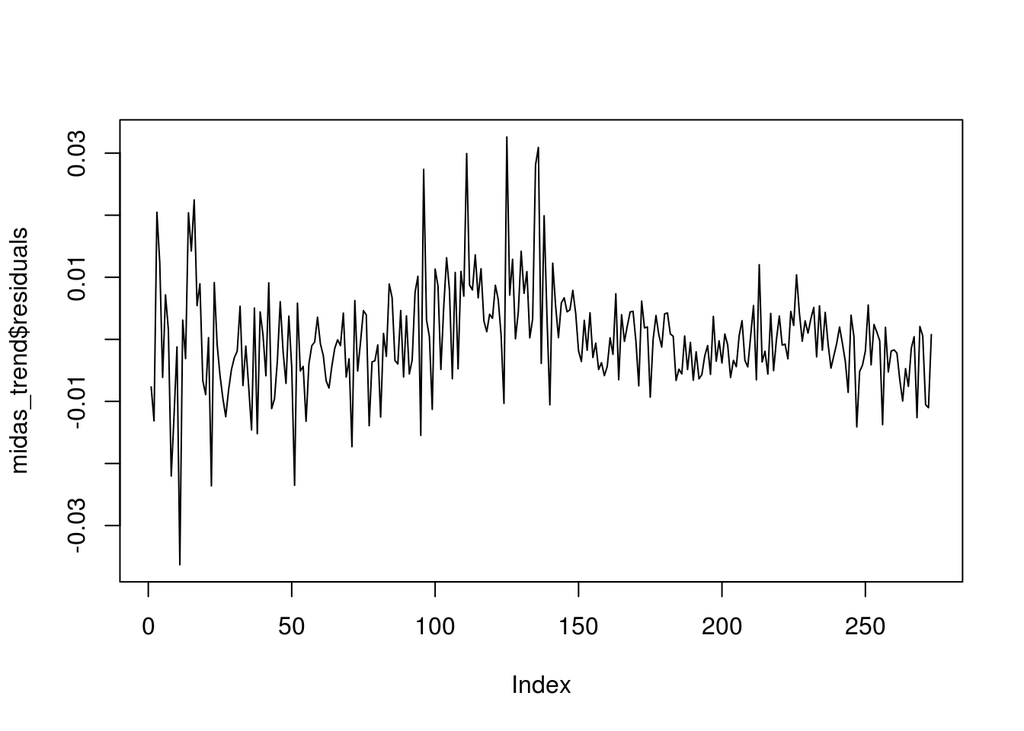

```r
plot(midas_trend$residuals, type='l')
```

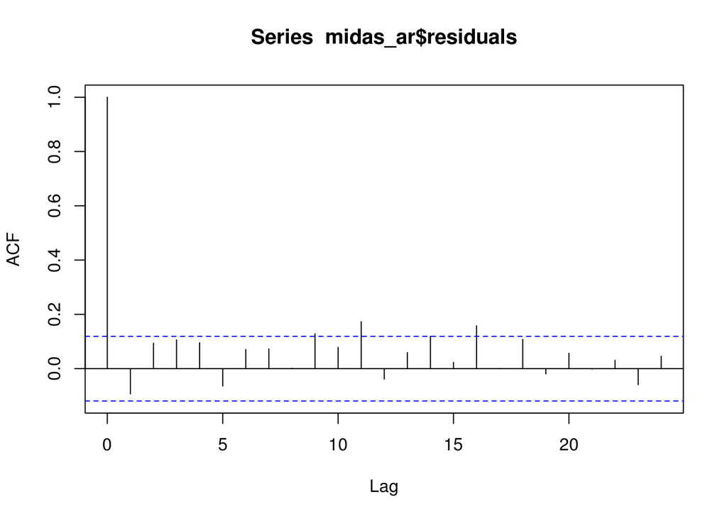

```r
#AR model
midas_ar <- midas_r(gdp_log_diff ~
                      mls(gdp_log_diff, 1, 1)+ mls(gdp_log_diff, 2, 1)  + mls(midas_employment_diff,0:2,3), start=NULL)

acf(midas_ar$residuals)
```

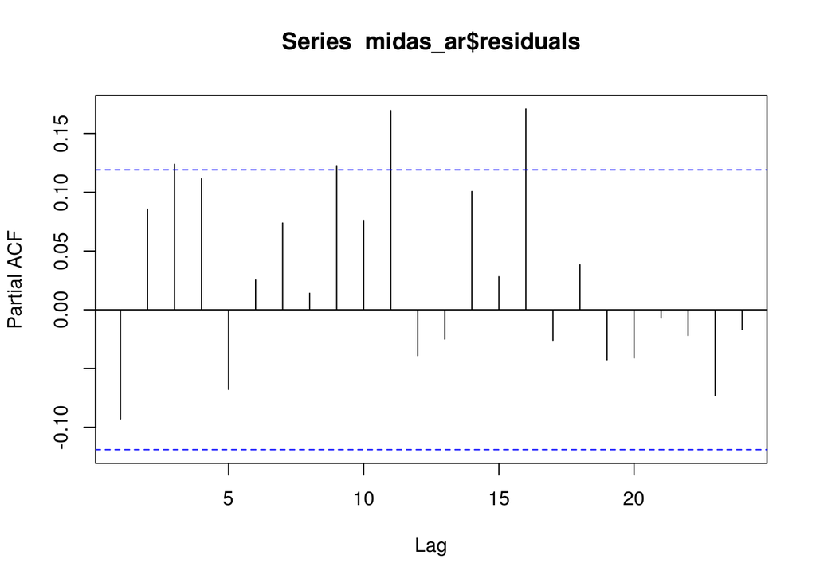

```r
pacf(midas_ar$residuals)
```

So the MIDAS AR(2) model is not perfect, but it would be intersting to take a look at this moving forward.

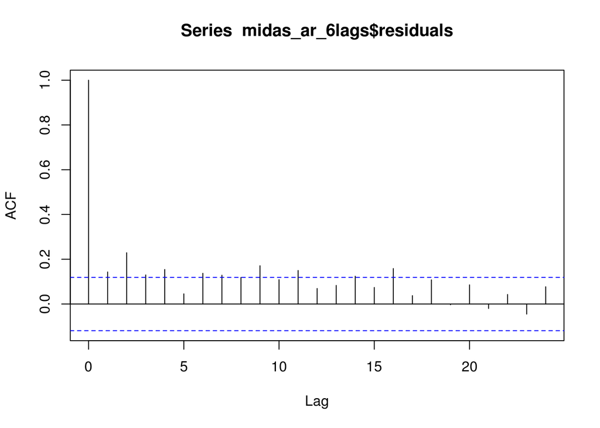

```r
# You can even look back further into the data than just 3 lags
midas_ar_6lags <- midas_r(gdp_log_diff ~
                      mls(gdp_log_diff, 1, 1)+ mls(gdp_log_diff, 2, 1)  + mls(midas_employment_diff,0:5,3), start=NULL)

acf(midas_ar_6lags$residuals)
```

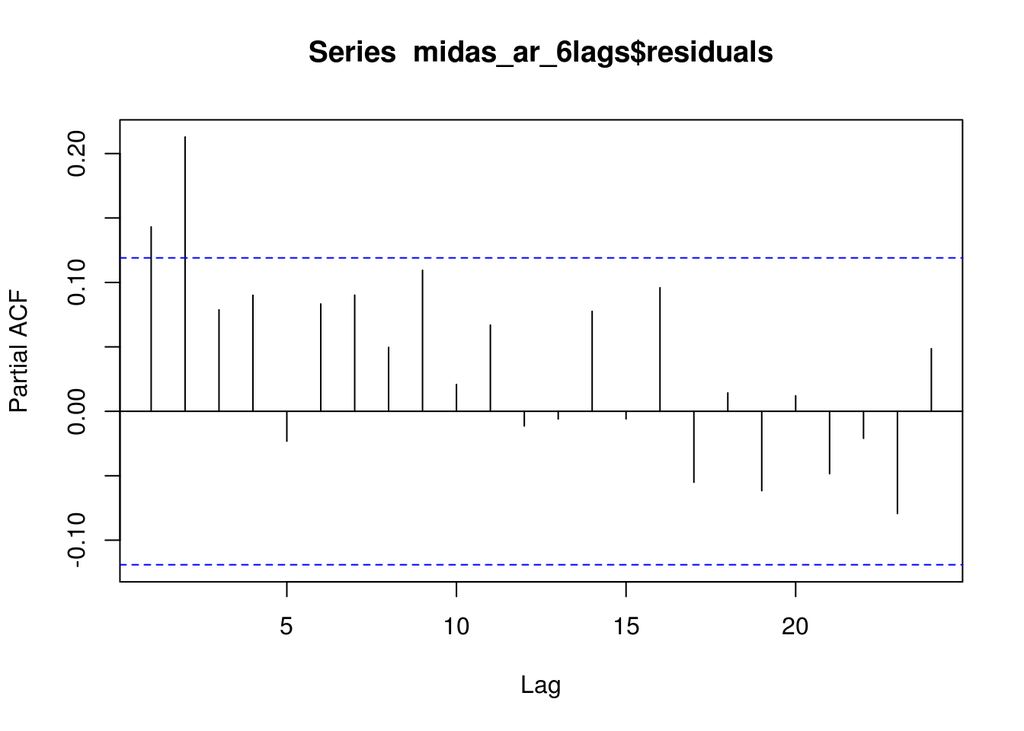

```r
pacf(midas_ar_6lags$residuals)
```

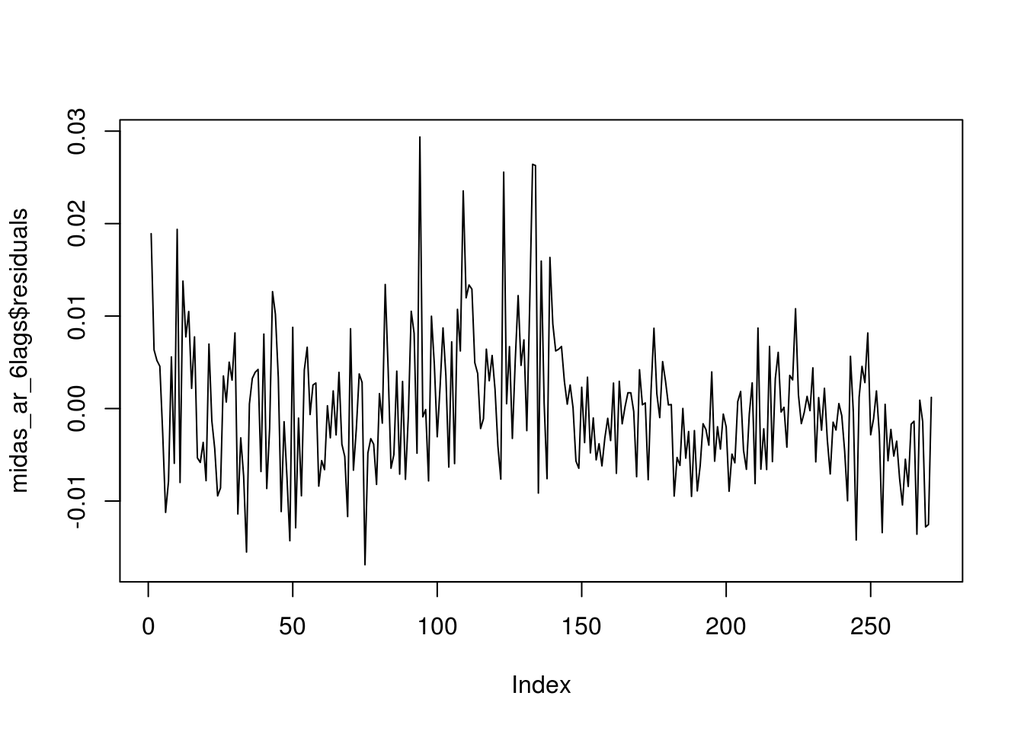

```r
plot(midas_ar_6lags$residuals, type='l')
```

```r
midas_ar2_4lags <- midas_r(gdp_log_diff ~
                      mls(gdp_log_diff, 1, 1) + mls(midas_employment_diff,0:3,3), start=NULL)

Box.test(midas_ar2_4lags$residuals,8,type='Ljung')
```

```
##
##  Box-Ljung test
##
## data:  midas_ar2_4lags$residuals
## X-squared = 58.815, df = 8, p-value = 7.957e-10
```

### Forcasting Values for the given models

```r
# set up the data frames
gdp_log_diff_forecast <- data.frame(gdp_log_diff)
em_log_diff_forecast <- data.frame(em_log_diff)
midas_employment_forecast<- data.frame(midas_employment_diff)

#create data frames for analysis and comparison
gdp_actual <- gdp_log_diff_forecast[c(270:273),]
em_log_diff_actual <- em_log_diff_forecast[c(270:273),]
midas_employment_actual <- midas_employment_forecast[c(808:819),]
midas_employment_actual<- data.frame(midas_employment_actual)
colnames(midas_employment_actual)<- c('employment')


#take out the last 4 GDPs
gdp_log_diff_forecast <- gdp_log_diff_forecast[-c(270:273),]
gdp_log_diff_forecast <- ts(gdp_log_diff_forecast)

#take out last 4 Employments
em_log_diff_forecast  <- em_log_diff_forecast [-c(270:273),]
em_log_diff_forecast  <- ts(em_log_diff_forecast)

#take 12 out of the midas
midas_employment_forecast <- midas_employment_forecast[-c(808:819),]
midas_employment_forecast <- data.frame(midas_employment_forecast)
```

```r
#take the handful of models you want to use and redo them
ar2_ma2_sa2_forecast <- arima(gdp_log_diff_forecast, order= c(2,0,2), seasonal = c(2,0,0))
ar2_ma2_predict <- predict(ar2_ma2_sa2_forecast, n.ahead= 4, newxreg = NULL)
#What is the predict static or dynamic?

#Arima with employment
ar_2_sa2_data_forecast <- arima(gdp_log_diff_forecast, order= c(2,0,2), seasonal = c(2,0,0), xreg = em_log_diff_forecast)
ar_2_sa2_data_predict <- predict(ar_2_sa2_data_forecast, n.ahead= 4, newxreg = em_log_diff_actual)

#Midas regression
#CANT FIGURE OUT HOW TO GET THE DATA TO BE GOOD
#midas_ar2_4lags_forecast <- midas_r(gdp_log_diff_forecast ~
#          mls(gdp_log_diff_forecast, 1, 1) + mls(midas_employment_forecast,0:3,3), start=NULL)

#midas_ar2_4lags_predict <- forecast(midas_ar2_4lags_forecast,
#          list(midas_employment_forecast=  data.frame(midas_employment_actual$employment)), se = TRUE, level = c(90, 95),
#          method = c("dynamic"))


#midas_ar2_4lags_predict <- forecast(midas_ar2_4lags_forecast,
#          list(midas_employment_forecast= future), se = TRUE, level = c(90, 95),
#          method = c("static"))

#nrow(midas_employment_actual$employment)

#insample= midas_employment_forecast

#simulate(midas_ar2_4lags_forecast, nsim = 4, , future = TRUE,
#newdata = matrix(midas_employment_actual$employment), insample = NULL, method = c("dynamic"),
#innov = NULL, show_progress = TRUE)
#test<- forecast(midas_ar_6lags, nsim = 4, future = FALSE)
# test<- simulate(midas_ar_6lags, nsim = 4, future = FALSE)

#midas_ar_6lags
#test<- simulate(midas_ar_6lags, nsim = 4, future = FALSE)
#CANT FIGURE OUT HOW TO GET THE DATA TO BE GOOD

#forecast(object, newdata = NULL, se = FALSE,
#level = c(80, 95), fan = FALSE, npaths = 999, method = c("static",
#"dynamic"), insample = get_estimation_sample(object),
#show_progress = TRUE, add_ts_info = FALSE, ...)
```

source(‘backtest.R’) backtest(ar2_ma2_sa2,gdp_log_diff,orig=2014.3, h=3)